# Group Project 1 | STAT 330

### Basic Scatterplot

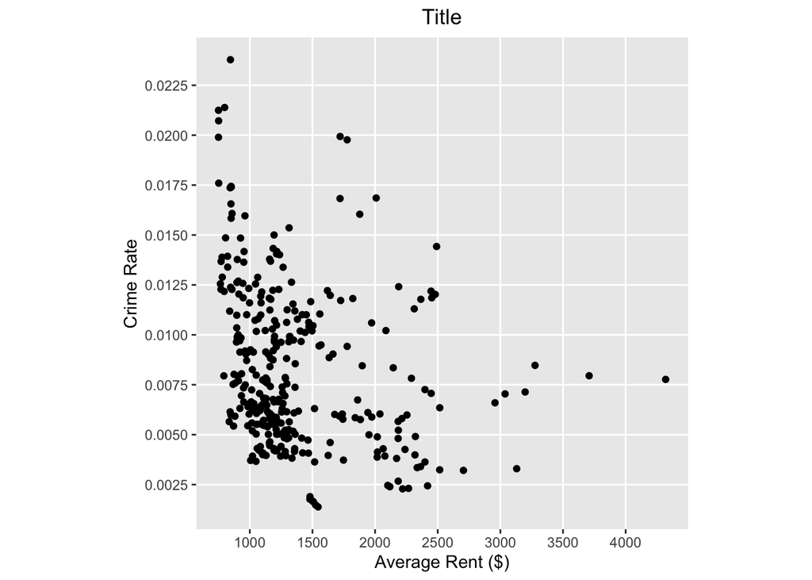

```r
data.base.plot <- ggplot(data = data, mapping = aes(x = Avg_rent, y = crime_rate)) +
  geom_point() +
  ggtitle("Title") +
  xlab("Average Rent ($)") +
  ylab("Crime Rate") +
  scale_x_continuous(breaks = seq(0, 4000, by = 500),
                     minor_breaks = seq(0, 4000, by = 500)) +
  scale_y_continuous(breaks = seq(0, 0.025, by = 0.0025),
                     minor_breaks = seq(0, 0.025, by = 0.0025)) +
  theme(aspect.ratio = 1, plot.title = element_text(hjust = 0.5))
data.base.plot
```

####The OLS regression line along with the scatterplot

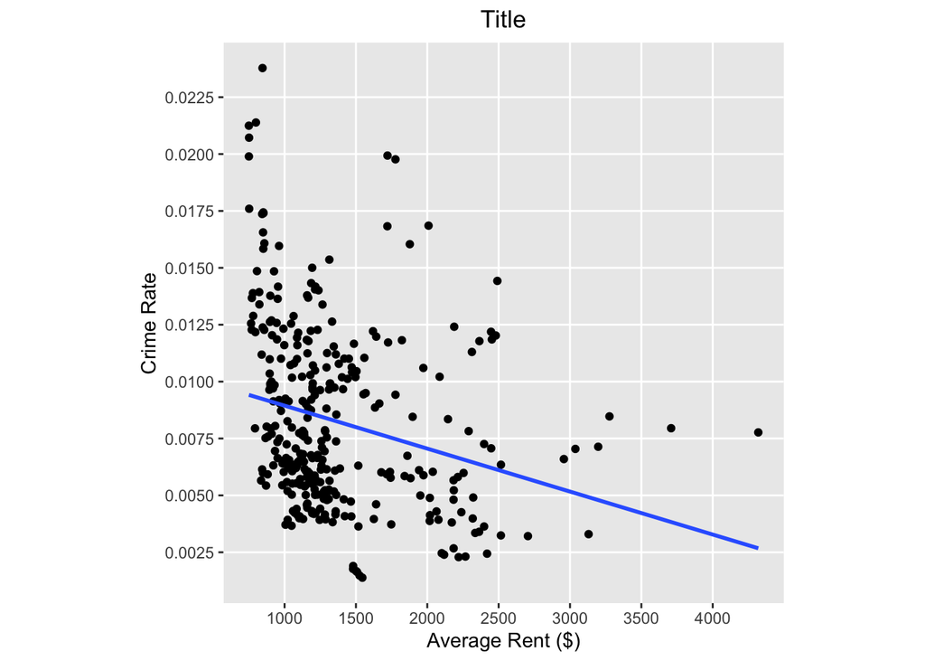

```r
data.base.plot + geom_smooth(method = "lm", se = FALSE)
```

#### Residuals vs. Fitted Values Plot

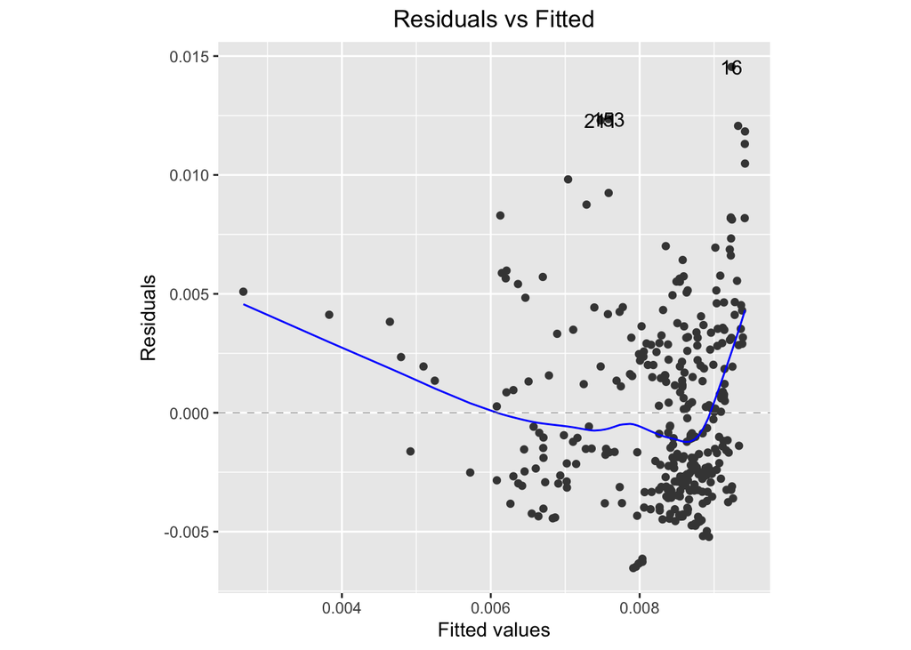

```r
autoplot(data.lm, which = 1, ncol = 1, nrow = 1) +
  theme(aspect.ratio = 1, plot.title = element_text(hjust = 0.5))
```

#### Residuals vs. Predictor Plot

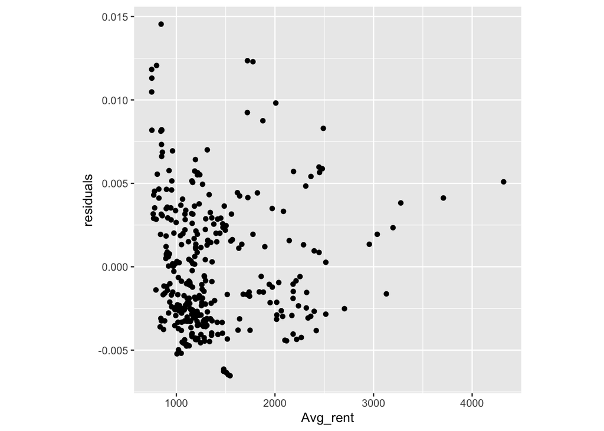

```r
ggplot(data = data, mapping = aes(y = residuals, x = Avg_rent)) +
  geom_point() +
  theme(aspect.ratio = 1)
```

#### Normal Probability Plot

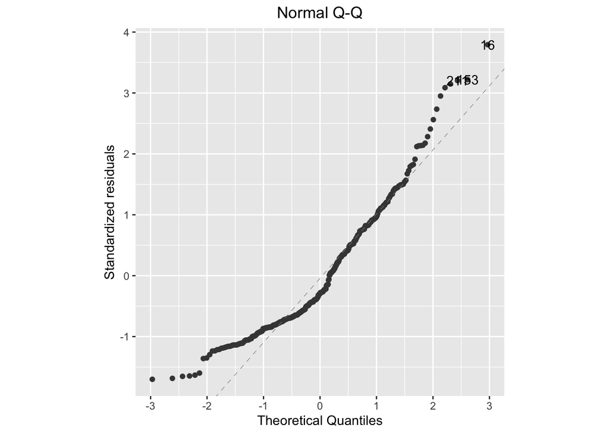

```r
autoplot(data.lm, which = 2, ncol = 1, nrow = 1) +
  theme(aspect.ratio = 1, plot.title = element_text(hjust = 0.5))
```

#### Histogram for residuals

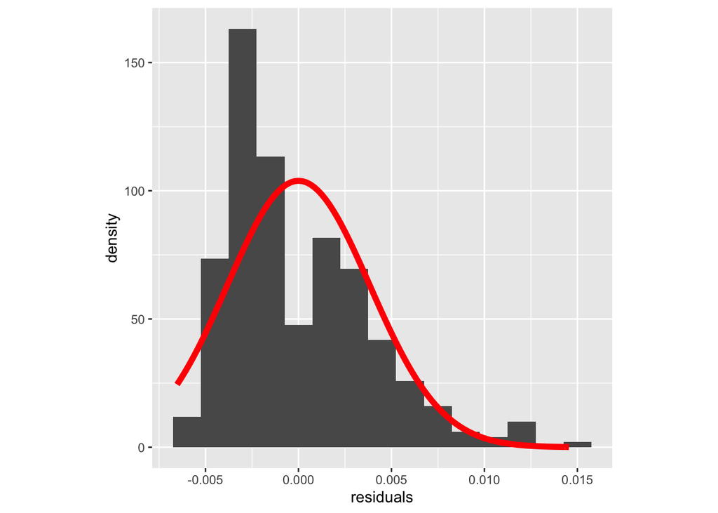

```r
ggplot(data = data, mapping = aes(x = residuals)) +
  geom_histogram(mapping = aes(y = ..density..), binwidth = 0.0015) +
  stat_function(fun = dnorm, color = "red", size = 2,
                args = list(mean = mean(data$residuals),
                            sd = sd(data$residuals))) +
  theme(aspect.ratio = 1)
```

#### Boxplot for residuals

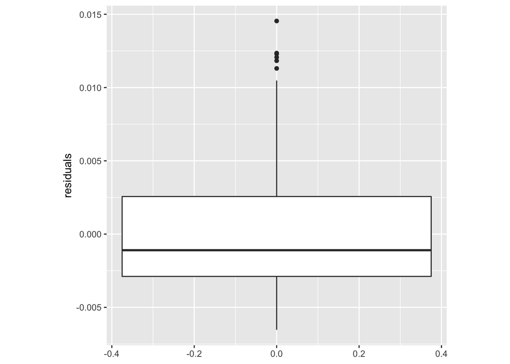

```r
ggplot(data = data, mapping = aes(y = residuals)) +
  geom_boxplot() +
  theme(aspect.ratio = 1)
```

#### Sequence Plot

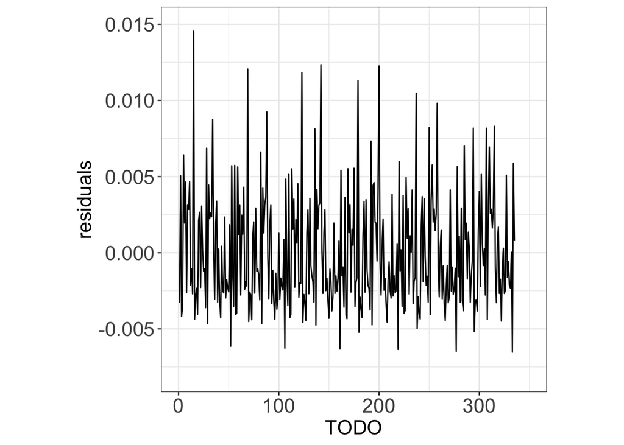

```r
ggplot(data) +
  geom_line(mapping = aes(x = 1:dim(data)[1], y = residuals)) +
  theme_bw() +
  scale_y_continuous(limits = c(-0.008, 0.015)) +
  scale_x_continuous(limits = c(0, 350)) +
  xlab("TODO") +
  theme(axis.title.x = element_text(size = sz),
        axis.title.y = element_text(size = sz),
        axis.text = element_text(size = sz),
        aspect.ratio = 1)
```

#### Shapiro-Wilk Test

```r
shapiro.test(data$residuals)
```

```
##
##  Shapiro-Wilk normality test
##
## data:  data$residuals
## W = 0.92982, p-value = 1.869e-11
```

#### Cook’s Distance

```r
data$cooksd <- cooks.distance(data.lm)
# Find n
data[data$cooksd >= 4 / length(data$cooksd), ]
```

```
##       X date          City State population violent_crimes homicides rapes
## 16   16 2010       Detroit    MI     713777          16973       310   403
## 37   37 2010       Oakland    CA     390724           6267        90   318
## 74   74 2011       Detroit    MI     713239          15254       344   426
## 95   95 2011       Oakland    CA     395317           6652       104   202
## 132 132 2012       Detroit    MI     707096          15023       386   442
## 145 145 2012       Memphis    TN     657436          11417       134   428
## 153 153 2012       Oakland    CA     399487           7963       127   271
## 173 173 2012    Washington    DC     632323           7448        88   236
## 190 190 2013       Detroit    MI     699889          14501       316   613
## 211 211 2013       Oakland    CA     403887           7984        90   180
## 224 224 2013 San Francisco    CA     833863           7064        48   161
## 231 231 2013    Washington    DC     646449           7880       103   393
## 248 248 2014       Detroit    MI     684694          13622       298   557
## 261 261 2014       Memphis    TN     654922          11420       139   519
```

[output cut: 77 more lines]

#### Brown-Forsythe Test

```r
grp <- as.factor(c(rep("lower", floor(dim(data)[1] / 2)),
                   rep("upper", ceiling(dim(data)[1] / 2))))
leveneTest(data[order(data$Avg_rent), "residuals"] ~ grp, center = median)
```

```
## Levene's Test for Homogeneity of Variance (center = median)
##        Df F value Pr(>F)
## group   1  0.0538 0.8168
##       333
```

#### DFBETAS

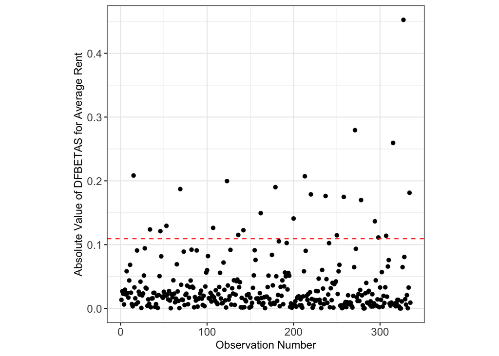

```r
# calculate the DFBETAS
data.dfbetas <- as.data.frame(dfbetas(data.lm))
# add the observation numbers to dataframe for plotting purposes
data.dfbetas$obs <- 1:length(data$Avg_rent)

# plot the DFBETAS against the observation number
ggplot(data = data.dfbetas) +
  geom_point(mapping = aes(x = obs, y = abs(Avg_rent))) +
  ylab("Absolute Value of DFBETAS for Average Rent") +
  xlab("Observation Number") +
  geom_hline(mapping = aes(yintercept = 2 / sqrt(length(obs))),
             color = "red", linetype = "dashed") +
  #scale_x_continuous(limits = c(0, 300)) +
  #scale_y_continuous(limits = c(0, 0.25)) +
  theme_bw() +
  theme(
    axis.title.x = element_text(size = sz - 5),
    axis.title.y = element_text(size = sz - 5),
    axis.text = element_text(size = sz - 5),
    aspect.ratio = 1,
    plot.title = element_blank()
  )
```

```r
# print a list of potential influential points according to DFBETAS
rent.extreme.dfbetas <- data.dfbetas[abs(data.dfbetas$Avg_rent) >
                                         2 / sqrt(length(data.dfbetas$obs)), ]
rent.extreme.dfbetas[order(rent.extreme.dfbetas$Avg_rent), ]
```

```
##     (Intercept)   Avg_rent obs
## 16   0.27075586 -0.2083583  15
## 132  0.24796481 -0.1996243 123
## 190  0.23627646 -0.1901111 179
## 74   0.23750369 -0.1871059  69
## 248  0.21893458 -0.1762475 237
## 306  0.16979765 -0.1365795 294
## 145  0.14950560 -0.1152078 136
## 261  0.14945458 -0.1146737 250
## 319  0.14855978 -0.1139024 307
## 310  0.08387975 -0.1111895 298
## 50  -0.10052897  0.1211044  46
## 153 -0.05008579  0.1226505 142
## 37  -0.07022139  0.1238256  34
## 115 -0.09274608  0.1262866 107
## 57  -0.09122747  0.1294689  53
## 211 -0.06746467  0.1409642 200
## 173 -0.11124223  0.1493598 162
## 289 -0.12909785  0.1699011 278
## 269 -0.11208712  0.1747951 258
## 231 -0.13570267  0.1788062 220
## 347 -0.13853980  0.1813057 334
## 224 -0.17285162  0.2071713 213
## 327 -0.19868015  0.2594568 315
## 282 -0.23822006  0.2794370 271
## 340 -0.39320015  0.4524122 327
```

#### DFFITS

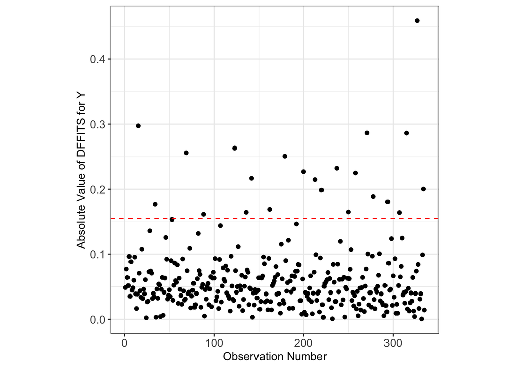

```r
# calculate the DFFITS
data.dffits <- data.frame("dffits" = dffits(data.lm))
# add the observation numbers to dataframe for plotting purposes
data.dffits$obs <- 1:length(data$crime_rate)

# plot the DFFITS against the observation number
ggplot(data = data.dffits) +
  geom_point(mapping = aes(x = obs, y = abs(dffits))) +
  ylab("Absolute Value of DFFITS for Y") +
  xlab("Observation Number") +
  geom_hline(mapping = aes(yintercept = 2 *
                             sqrt(length(data.lm$coefficients) / length(obs))),
             color = "red", linetype = "dashed") +
  theme_bw() +
  #scale_x_continuous(limits = c(0, 300)) +
  #scale_y_continuous(limits = c(0, 0.3)) +
  theme(
    axis.title.x = element_text(size = sz - 5),
    axis.title.y = element_text(size = sz - 5),
    axis.text = element_text(size = sz - 5),
    aspect.ratio = 1,
    plot.title = element_blank()
  )
```

```r
# print a list of potential influential points according to DFFITS
data.dffits[abs(data.dffits$dffits) > 2 *
             sqrt(length(data.lm$coefficients) / length(data.dffits$obs)), ]
```

```
##        dffits obs
## 16  0.2973717  15
## 37  0.1765822  34
## 74  0.2561031  69
## 95  0.1609833  88
## 132 0.2631680 123
## 145 0.1640226 136
## 153 0.2168186 142
## 173 0.1685492 162
## 190 0.2508595 179
## 211 0.2270426 200
## 224 0.2148138 213
## 231 0.1986201 220
## 248 0.2323635 237
## 261 0.1645369 250
## 269 0.2250142 258
## 282 0.2863410 271
## 289 0.1885428 278
## 306 0.1803168 294
## 319 0.1636505 307
## 327 0.2861023 315
## 340 0.4594826 327
## 347 0.2002731 334
```

### Assumption Checking for The Model

#### X vs Y is linear

X vs Y is not linear, since the scatterplot does not look roughly linear and does not look like a line can be easily fitted to the data. As well the Residuals vs Fitted values plot shows that the blue line is not roughly horizontal with heavy curvature.

#### The residuals are independent

The residuals seem not to be independent since crimes the recorded are only observed or reported to the FBI. Crime in general is not random but premeditated. However, average rent is more likely to be skewed by heavy outliers in cities depending on the area. Median rent prices might be a better indicator.